# NHS Wales Data

Mark Baber

2021

# Web Scraping NHS Wales

This report will go over the steps taken to web scrape data from an NHS Wales website. This involves:

- Downloading the files into rstudio
- Carrying out some EDA
- Plotting the data
- Feature Extraction/Creation

This report will also try to keep to a Gold Standard, which will be adapted from this [blog post.](https://towardsdatascience.com/the-gold-standard-of-data-science-project-management-13d68c9e85d6)

## 0 - Set a Working Directory

Usually when working within R, I start by creating a new folder and a project file, this can be done via the gui (top right of rstudio) or via the console.

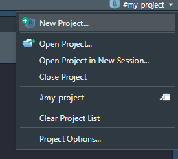

Create Project Via RStudio

Whilst I often switch between operating systems (Linux & Windows) this isn’t always an ideal way of setting the project, especially when using online cloud storage. This works much better via Git && Github.

## 1 - EDA

Firstly, when working with scripts and data science coding, it is usually very helpful to set the seed, for reproducibility.

For the seed I set it as my student number from USW - but can be anything.

Next would be to set the libraries which could be useful throughout this report, most jobs within r can be done with the base set libraries, but sometimes it’s fun to explore other methods which make some tasks a lot easier/faster. These packages aren’t set in stone, and are dynamic for this report.

```
## funModeling v.1.9.4 :)
## Examples and tutorials at livebook.datascienceheroes.com
##  / Now in Spanish: librovivodecienciadedatos.ai
```

Next would be to import the data, this part proved to be quite difficult as I kept getting different errors when trying to download the files locally. I will add the code just in case I find something which sparks an idea.

## 2 - Meta Data

[GP Practice Analysis and Patient Registrations by Practice](https://nwssp.nhs.wales/ourservices/primary-care-services/general-information/data-and-publications/gp-practice-analysis/)

> The data shows the number of items prescribed by each practice by month and the number of patients registered with each practice. Data relating to patient registrations by practice is extracted from NHAIS (National Health Application and Infrastructure Services) system each quarter. The Health Board, practice code, postcode and count by age band and gender are included. Please note that patients 95 and over have been grouped together due to potential risk of disclosure.
- Whilst also keeping a note of patient transfers.

With a better idea of the data after looking at the meta data above, this will give us a better idea of what to look for within the dataset - and a good reminder for us throughout the report.

The above snippet (which is all commented out and won’t be be printed) looks like it worked, however when I try to import the data and have a look at it, the data has been squashed together into 2 columns - My thought is that the file is failing to download correctly, but I’m unsure why (as I can download the package via the command line (Bash) or by clicking on it.)

This is the best I could do whilst trying to download a file from the NHS Wales website, this was done with the extension ‘.xlsx’ and without. So I will download them **manually** by just clicking the links on the website and saving them to a data folder within my project.

Now that we have created 6 data frames each containing a month of GP visits, these are taken quarterly by the look at: - Jan - April - July - October

## 2 - Data Wrangling

[Data Wrangling](https://xseedcap.com/news-article/big-data-scientists-janitor-work-key-hurdle-insights/) - Accessed 01/08/2021

Data Wrangling has been described as the Janitor Work for data scientists, and is said to take up to 50 - 80 percent of any data scientists time (Ref). With this being the case, this part of the report could become quite large and possibly overwhelming. To over come this, lets break down each part and focus on one stage at a time.

Here we now have 6 datasets from the same source, whilst these 6 datasets could be explored one at a time, lets try to combine these datasets and explore the data as a whole. First we would need to inspect the datasets to make sure they’re following the same structure throughout. An easy way to check the columns is by using the function *names*.

```
## [1] "Period"             "PracticeCode"       "PostCode"
## [4] "OrgCode"            "AgeBand"            "MaleCount"
## [7] "FemaleCount"        "IndeterminateCount" "Count"
```

```
## [1] "Period"             "PracticeCode"       "PostCode"
## [4] "OrgCode"            "AgeBand"            "MaleCount"
## [7] "FemaleCount"        "IndeterminateCount" "Count"
```

```
## [1] "Period"             "PracticeCode"       "PostCode"
## [4] "OrgCode"            "AgeBand"            "MaleCount"
## [7] "FemaleCount"        "IndeterminateCount" "Count"
```

```
## [1] "Period"             "PracticeCode"       "PostCode"
## [4] "OrgCode"            "AgeBand"            "MaleCount"
## [7] "FemaleCount"        "IndeterminateCount" "Count"
```

```
##  [1] "Period"             "PracticeCode"       "postcode"
##  [4] "OrgCode"            "HAName"             "AgeBand"
##  [7] "MaleCount"          "Femalecount"        "Indeterminatecount"
## [10] "count"
```

```
##  [1] "Period"             "PracticeCode"       "postcode"
##  [4] "OrgCode"            "HAName"             "AgeBand"
##  [7] "MaleCount"          "Femalecount"        "Indeterminatecount"
## [10] "count"
```

Here we can see that the last 2 data frames have an additional column, *HAName*. From what I can tell, this is the Local Health Board which is also denoted by the OrgCode - To make things easier, lets grab the Local Health Boards, figure out which one refers to which code, and replace the code with the LHB.

To begin, lets create a data frame and get the unique Health Boards.

```
## [1] "Aneurin Bevan"         "Betsi Cadwaladr Uni"   "Hywel Dda"
## [4] "Cardiff And Vale Uni"  "Cwm Taf Morgannwg UHB" "Swansea Bay UHB"
## [7] "Powys Teaching"
```

Now we can see the LHBs, we can use these to filter one of the newer data frames which has the HAName/LHB.

Above we have filtered out the LHBs from the latest data frame, next we can check each filtered data frame for the OrgCode.

```
## [1] "AB   = 7A6"
```

```
## [1] "BC   = 7A1"
```

```
## [1] "HD   = 7A2"
```

```
## [1] "CV   = 7A4"
```

```
## [1] "CTM  = 7A5"
```

```
## [1] "SB   = 7A3"
```

```
## [1] "PT   = 7A7"
```

Now we know: - 7A1 - Betsi Cadwaladr Uni - 7A2 - Hywel Dda - 7A3 - Swansea Bay UHB - 7A4 - Cardiff And Vale Uni - 7A5 - Cwm Taf Morgannwg UHB - 7A6 - Aneurin Bevan - 7A7 - Powys Teaching

Now that we have the HBs saved and filtered, we can drop those columns from the newer datasets, combine the datasets and then add the HBs back in (in place of the OrgCode). This is a bit over the top, and there is bound to be a better way of doing things.

Here we have dropped the 5th column which is HAName. Next lets look at getting the column names from the older datasets (double check they’re the same for the others) and make sure all column names are the same. *(I noticed the modern datasets didn’t have the same capitalization on the columns, hence the next steps.)*

Before combining the datasets into something massive, lets try and create a new column for year and month (This was very difficult doing it within a loop on the joined dataset.)

With the Year and Month cols created (and much easier than trying to run it in a conditional loop), we can merge the dfs with rbind and drop the period col.

Here we can see that the data frame was created without any issues. Lets replace the column OrgCode for the Health Board - and rename the column name afterwards.

```
## [1] "Aneurin Bevan"         "Betsi Cadwaladr Uni"   "Hywel Dda"
## [4] "Cardiff And Vale Uni"  "Cwm Taf Morgannwg UHB" "Swansea Bay UHB"
## [7] "Powys Teaching"
```

Lets quickly rename OrgCodes to Health Board so it is a bit easier to understand.

```
##  [1] "PracticeCode"       "PostCode"           "healthboard"
##  [4] "AgeBand"            "MaleCount"          "FemaleCount"
##  [7] "IndeterminateCount" "Count"              "Year"
## [10] "Month"
```

Great - now we have a combined dataset (More datasets could be added to make things better, for example lsoa which will hopefully be explored later.) lets remove the older data frames to clear up some memory.

```
## [1] 2020 2021
```

```
## [1] "April"   "July"    "October" "January"
```

This next part will be omitted

Preparing the dataset for additional data, first the dataset needs to follow a few rules which I tend to follow:

- remove spaces between postcodes (you’ll see why soon)
- all lowercase

Next I want to try and add the Welsh Index of Multiple Deprivation - this dataset could be used to get a better understanding of each LSOA. From the dataset I found on [Postcode to WIMD rank lookup](https://statswales.gov.wales/Download/File?fileId=637) the postcodes don’t have any white-space, hence why we just removed the white-space above.

I’ve also noticed that the dataset is formatted as an **ods** file, which can be converted with Excel. After getting the file into an XLSX format, we can import the dataset.

```
## [1] "postcode"              "lsoa code"             "lsoa name"
## [4] "lsoa name (cymraeg)"   "wimd lsoa rank"        "wimd overall decile"
## [7] "wimd overall quintile" "wimd overall quartile"
```

| postcode | lsoa code | lsoa name | lsoa name (cymraeg) | wimd lsoa rank | wimd overall decile | wimd overall quintile | wimd overall quartile |
| --- | --- | --- | --- | --- | --- | --- | --- |
| LL309EF | W01000187 | Tudno 2 | Tudno 2 | 78 | 1 | 1 | 1 |
| LL319XX | W01000176 | Pensarn 1 | Pen-sarn 1 | 759 | 4 | 2 | 2 |
| NP64AT | W01001542 | Caerwent | Caer-went | 1505 | 8 | 4 | 4 |
| SY225DH | W01000461 | Llanfyllin | Llanfyllin | 888 | 5 | 3 | 2 |
| SA659BA | W01000566 | Fishguard North West | Abergwaun Gogledd Orllewin | 936 | 5 | 3 | 2 |
| LL414UG | W01000114 | Trawsfynydd | Trawsfynydd | 1119 | 6 | 3 | 3 |
| NPT6JQ | W01001653 | Malpas 3 | Malpas 3 | 1627 | 9 | 5 | 4 |
| CF103ZG | W01001759 | Grangetown 1 | Grangetown 1 | 796 | 5 | 3 | 2 |
| NP166SY | W01001583 | St. Arvans | St. Arvans | 1382 | 8 | 4 | 3 |
| CF311BE | W01001021 | Morfa 1 | Morfa 1 | 397 | 3 | 2 | 1 |

[output cut: 40 more lines]

| practicecode | postcode | healthboard | ageband | malecount | femalecount | indeterminatecount | count | year | month | lsoa_code | lsoa_name | lsoa_name_(cymraeg) | wimd_lsoa_rank | wimd_overall_decile | wimd_overall_quintile | wimd_overall_quartile |
| --- | --- | --- | --- | --- | --- | --- | --- | --- | --- | --- | --- | --- | --- | --- | --- | --- |
| W00005 | CF834AZ | Aneurin Bevan | 0 | 33 | 35 | 0 | 68 | 2020 | April | W01001331 | Aber Valley 2 | Cwm Aber 2 | 633 | 4 | 2 | 2 |
| W00005 | CF834AZ | Aneurin Bevan | 1 | 42 | 47 | 0 | 89 | 2020 | April | W01001331 | Aber Valley 2 | Cwm Aber 2 | 633 | 4 | 2 | 2 |
| W00005 | CF834AZ | Aneurin Bevan | 2 | 41 | 42 | 0 | 83 | 2020 | April | W01001331 | Aber Valley 2 | Cwm Aber 2 | 633 | 4 | 2 | 2 |
| W00005 | CF834AZ | Aneurin Bevan | 3 | 43 | 56 | 0 | 99 | 2020 | April | W01001331 | Aber Valley 2 | Cwm Aber 2 | 633 | 4 | 2 | 2 |
| W00005 | CF834AZ | Aneurin Bevan | 4 | 36 | 56 | 0 | 92 | 2020 | April | W01001331 | Aber Valley 2 | Cwm Aber 2 | 633 | 4 | 2 | 2 |
| W00005 | CF834AZ | Aneurin Bevan | 5 | 51 | 48 | 0 | 99 | 2020 | April | W01001331 | Aber Valley 2 | Cwm Aber 2 | 633 | 4 | 2 | 2 |

Next I would like to merge a dataset which found the *County* for the postcodes & LSOA. I’ve added this with the hopes of adding housing dataset. This was done by looking at the LSOAs found within the dataset and creating an If Else script within Excel to pull out the County per LSOA.

This was from [GOV.Wales](https://gov.wales/docs/statistics/lsoamaps/lsoa.htm) and can be found within “../data/tidy/lsoa-to-county.xlsx” with the the code in the first column which helped a lot.

This dataset has a best fit Area maps for each LSOA within Wales, with 1896 LSOAs in Wales each with an estimates population of around 1500 people.

| practicecode | postcode | healthboard | ageband | malecount | femalecount | indeterminatecount | count | year | month | lsoa_code | lsoa_name | lsoa_name_(cymraeg) | wimd_lsoa_rank | wimd_overall_decile | wimd_overall_quintile | wimd_overall_quartile | county |
| --- | --- | --- | --- | --- | --- | --- | --- | --- | --- | --- | --- | --- | --- | --- | --- | --- | --- |
| W00005 | CF834AZ | Aneurin Bevan | 0 | 33 | 35 | 0 | 68 | 2020 | April | W01001331 | Aber Valley 2 | Cwm Aber 2 | 633 | 4 | 2 | 2 | Caerphilly |
| W00005 | CF834AZ | Aneurin Bevan | 1 | 42 | 47 | 0 | 89 | 2020 | April | W01001331 | Aber Valley 2 | Cwm Aber 2 | 633 | 4 | 2 | 2 | Caerphilly |
| W00005 | CF834AZ | Aneurin Bevan | 2 | 41 | 42 | 0 | 83 | 2020 | April | W01001331 | Aber Valley 2 | Cwm Aber 2 | 633 | 4 | 2 | 2 | Caerphilly |
| W00005 | CF834AZ | Aneurin Bevan | 3 | 43 | 56 | 0 | 99 | 2020 | April | W01001331 | Aber Valley 2 | Cwm Aber 2 | 633 | 4 | 2 | 2 | Caerphilly |
| W00005 | CF834AZ | Aneurin Bevan | 4 | 36 | 56 | 0 | 92 | 2020 | April | W01001331 | Aber Valley 2 | Cwm Aber 2 | 633 | 4 | 2 | 2 | Caerphilly |
| W00005 | CF834AZ | Aneurin Bevan | 5 | 51 | 48 | 0 | 99 | 2020 | April | W01001331 | Aber Valley 2 | Cwm Aber 2 | 633 | 4 | 2 | 2 | Caerphilly |

Another dataset which could be added now would be *New dwellings started by local authority*. Based on the suggestion that it takes an average of two years to build a house in the UK, I have taken the earliest point in the dataset (April 2020) and backtracked two full years to take a sample from the ‘New dwellings started by local authority area and dwelling type’ dataset (Stats Wales ref).

This is based on the assumption that houses recorded as being in the process of being built then, would be becoming available on the market approximately April 20202. The alternative was to use the dataset ‘New dwellings completed by period and tenure’ and measure houses that were available on the market, but this was more difficult as the dataset was not available by county and requires significant effort to combine and clean.

[Link to dataset](https://statswales.gov.wales/Catalogue/Housing/New-House-Building/newdwellingsstarted-by-area-dwellingtype) with the [Link to alternative dataset found here.](https://statswales.gov.wales/Catalogue/Housing/New-House-Building/newdwellingscompleted-by-period-tenure)

| practicecode | postcode | healthboard | ageband | malecount | femalecount | indeterminatecount | count | year | month | lsoa_code | lsoa_name | lsoa_name_(cymraeg) | wimd_lsoa_rank | wimd_overall_decile | wimd_overall_quintile | wimd_overall_quartile | county | total | houses | flats |
| --- | --- | --- | --- | --- | --- | --- | --- | --- | --- | --- | --- | --- | --- | --- | --- | --- | --- | --- | --- | --- |
| W00005 | CF834AZ | Aneurin Bevan | 0 | 33 | 35 | 0 | 68 | 2020 | April | W01001331 | Aber Valley 2 | Cwm Aber 2 | 633 | 4 | 2 | 2 | Caerphilly | 19 | 15 | 4 |
| W00005 | CF834AZ | Aneurin Bevan | 1 | 42 | 47 | 0 | 89 | 2020 | April | W01001331 | Aber Valley 2 | Cwm Aber 2 | 633 | 4 | 2 | 2 | Caerphilly | 19 | 15 | 4 |
| W00005 | CF834AZ | Aneurin Bevan | 2 | 41 | 42 | 0 | 83 | 2020 | April | W01001331 | Aber Valley 2 | Cwm Aber 2 | 633 | 4 | 2 | 2 | Caerphilly | 19 | 15 | 4 |
| W00005 | CF834AZ | Aneurin Bevan | 3 | 43 | 56 | 0 | 99 | 2020 | April | W01001331 | Aber Valley 2 | Cwm Aber 2 | 633 | 4 | 2 | 2 | Caerphilly | 19 | 15 | 4 |
| W00005 | CF834AZ | Aneurin Bevan | 4 | 36 | 56 | 0 | 92 | 2020 | April | W01001331 | Aber Valley 2 | Cwm Aber 2 | 633 | 4 | 2 | 2 | Caerphilly | 19 | 15 | 4 |
| W00005 | CF834AZ | Aneurin Bevan | 5 | 51 | 48 | 0 | 99 | 2020 | April | W01001331 | Aber Valley 2 | Cwm Aber 2 | 633 | 4 | 2 | 2 | Caerphilly | 19 | 15 | 4 |

| ageband | count | county | femalecount | flats | healthboard | houses | indeterminatecount | lsoa_code | lsoa_name | lsoa_name_(cymraeg) | malecount | month | postcode | practicecode | total | wimd_lsoa_rank | wimd_overall_decile | wimd_overall_quartile | wimd_overall_quintile | year |
| --- | --- | --- | --- | --- | --- | --- | --- | --- | --- | --- | --- | --- | --- | --- | --- | --- | --- | --- | --- | --- |
| 0 | 68 | Caerphilly | 35 | 4 | Aneurin Bevan | 15 | 0 | W01001331 | Aber Valley 2 | Cwm Aber 2 | 33 | April | CF834AZ | W00005 | 19 | 633 | 4 | 2 | 2 | 2020 |
| 1 | 89 | Caerphilly | 47 | 4 | Aneurin Bevan | 15 | 0 | W01001331 | Aber Valley 2 | Cwm Aber 2 | 42 | April | CF834AZ | W00005 | 19 | 633 | 4 | 2 | 2 | 2020 |
| 2 | 83 | Caerphilly | 42 | 4 | Aneurin Bevan | 15 | 0 | W01001331 | Aber Valley 2 | Cwm Aber 2 | 41 | April | CF834AZ | W00005 | 19 | 633 | 4 | 2 | 2 | 2020 |
| 3 | 99 | Caerphilly | 56 | 4 | Aneurin Bevan | 15 | 0 | W01001331 | Aber Valley 2 | Cwm Aber 2 | 43 | April | CF834AZ | W00005 | 19 | 633 | 4 | 2 | 2 | 2020 |
| 4 | 92 | Caerphilly | 56 | 4 | Aneurin Bevan | 15 | 0 | W01001331 | Aber Valley 2 | Cwm Aber 2 | 36 | April | CF834AZ | W00005 | 19 | 633 | 4 | 2 | 2 | 2020 |
| 5 | 99 | Caerphilly | 48 | 4 | Aneurin Bevan | 15 | 0 | W01001331 | Aber Valley 2 | Cwm Aber 2 | 51 | April | CF834AZ | W00005 | 19 | 633 | 4 | 2 | 2 | 2020 |

Whilst I try to do things efficiently, it is also important to be mindful of tidy data. There are a few rules to tidy data as stated by Hadley Wickham:

1 - Every column is a variable 2 - Every row is an observation 3 - Every cell is a single value

This was adapted from the [R for Data Science](https://r4ds.had.co.nz/index.html). This is where I got the idea for Year and Month to be separate, but did it before the binding of the data frames above. Seeing as that part was done, lets begin some actual EDA.

## 3 - Exploratory Data Analysis

Lets now go through the dataset and get a better understanding of the structure, the data, and just explore the data.

```
## tibble [224,804 x 21] (S3: tbl_df/tbl/data.frame)
##  $ ageband              : num [1:224804] 0 1 2 3 4 5 6 7 8 9 ...
##  $ count                : num [1:224804] 68 89 83 99 92 99 85 92 88 92 ...
##  $ county               : chr [1:224804] "Caerphilly" "Caerphilly" "Caerphilly" "Caerphilly" ...
##  $ femalecount          : num [1:224804] 35 47 42 56 56 48 43 42 38 38 ...
##  $ flats                : num [1:224804] 4 4 4 4 4 4 4 4 4 4 ...
##  $ healthboard          : chr [1:224804] "Aneurin Bevan" "Aneurin Bevan" "Aneurin Bevan" "Aneurin Bevan" ...
##  $ houses               : num [1:224804] 15 15 15 15 15 15 15 15 15 15 ...
##  $ indeterminatecount   : num [1:224804] 0 0 0 0 0 0 0 0 0 0 ...
##  $ lsoa_code            : chr [1:224804] "W01001331" "W01001331" "W01001331" "W01001331" ...
##  $ lsoa_name            : chr [1:224804] "Aber Valley 2" "Aber Valley 2" "Aber Valley 2" "Aber Valley 2" ...
##  $ lsoa_name_(cymraeg)  : chr [1:224804] "Cwm Aber 2" "Cwm Aber 2" "Cwm Aber 2" "Cwm Aber 2" ...
##  $ malecount            : num [1:224804] 33 42 41 43 36 51 42 50 50 54 ...
##  $ month                : chr [1:224804] "April" "April" "April" "April" ...
##  $ postcode             : chr [1:224804] "CF834AZ" "CF834AZ" "CF834AZ" "CF834AZ" ...
##  $ practicecode         : chr [1:224804] "W00005" "W00005" "W00005" "W00005" ...
##  $ total                : num [1:224804] 19 19 19 19 19 19 19 19 19 19 ...
##  $ wimd_lsoa_rank       : num [1:224804] 633 633 633 633 633 633 633 633 633 633 ...
##  $ wimd_overall_decile  : num [1:224804] 4 4 4 4 4 4 4 4 4 4 ...
##  $ wimd_overall_quartile: num [1:224804] 2 2 2 2 2 2 2 2 2 2 ...
##  $ wimd_overall_quintile: num [1:224804] 2 2 2 2 2 2 2 2 2 2 ...
##  $ year                 : num [1:224804] 2020 2020 2020 2020 2020 2020 2020 2020 2020 2020 ...
```

- ageband - the patients age.
- count - the total number of visits (males, female, intersex maybe).
- county - the local county.
- femalecount - the number of female visits.
- healthboard - the gps health board (aneurin bevan, cardiff etc).
- indeterminatecount - the number of intersex visits.
- lsoa_code - the lower layer super output area code.
- lsoa_name - lower layer super output area.
- lsoa_name(cymraeg) - lower layer super output area.
- malecount - the number of male visits.
- month - the month.
- postcode - the gps postcode.
- practice_code - the gps practice code.
- wimd_lsoa_rank - welsh index of multiple deprivation lsoa rank (lower is worse)
- wimd_overall_decile
- wimd_overall_quartile
- wimd_overall_quintile
- year - the year.

We can also look at the data via the head and tail.

| ageband | count | county | femalecount | flats | healthboard | houses | indeterminatecount | lsoa_code | lsoa_name | lsoa_name_(cymraeg) | malecount | month | postcode | practicecode | total | wimd_lsoa_rank | wimd_overall_decile | wimd_overall_quartile | wimd_overall_quintile | year |
| --- | --- | --- | --- | --- | --- | --- | --- | --- | --- | --- | --- | --- | --- | --- | --- | --- | --- | --- | --- | --- |
| 0 | 68 | Caerphilly | 35 | 4 | Aneurin Bevan | 15 | 0 | W01001331 | Aber Valley 2 | Cwm Aber 2 | 33 | April | CF834AZ | W00005 | 19 | 633 | 4 | 2 | 2 | 2020 |
| 1 | 89 | Caerphilly | 47 | 4 | Aneurin Bevan | 15 | 0 | W01001331 | Aber Valley 2 | Cwm Aber 2 | 42 | April | CF834AZ | W00005 | 19 | 633 | 4 | 2 | 2 | 2020 |
| 2 | 83 | Caerphilly | 42 | 4 | Aneurin Bevan | 15 | 0 | W01001331 | Aber Valley 2 | Cwm Aber 2 | 41 | April | CF834AZ | W00005 | 19 | 633 | 4 | 2 | 2 | 2020 |
| 3 | 99 | Caerphilly | 56 | 4 | Aneurin Bevan | 15 | 0 | W01001331 | Aber Valley 2 | Cwm Aber 2 | 43 | April | CF834AZ | W00005 | 19 | 633 | 4 | 2 | 2 | 2020 |
| 4 | 92 | Caerphilly | 56 | 4 | Aneurin Bevan | 15 | 0 | W01001331 | Aber Valley 2 | Cwm Aber 2 | 36 | April | CF834AZ | W00005 | 19 | 633 | 4 | 2 | 2 | 2020 |
| 5 | 99 | Caerphilly | 48 | 4 | Aneurin Bevan | 15 | 0 | W01001331 | Aber Valley 2 | Cwm Aber 2 | 51 | April | CF834AZ | W00005 | 19 | 633 | 4 | 2 | 2 | 2020 |

| ageband | count | county | femalecount | flats | healthboard | houses | indeterminatecount | lsoa_code | lsoa_name | lsoa_name_(cymraeg) | malecount | month | postcode | practicecode | total | wimd_lsoa_rank | wimd_overall_decile | wimd_overall_quartile | wimd_overall_quintile | year |
| --- | --- | --- | --- | --- | --- | --- | --- | --- | --- | --- | --- | --- | --- | --- | --- | --- | --- | --- | --- | --- |
| NA | 25 | Swansea | 20 | 9 | Swansea Bay UHB | 52 | 0 | W01000850 | St. Thomas 2 | St. Thomas 2 | 5 | July | SA18QY | W98056 | 61 | 484 | 3 | 2 | 2 | 2021 |
| NA | 18 | Swansea | 15 | 9 | Swansea Bay UHB | 52 | 0 | W01000850 | St. Thomas 2 | St. Thomas 2 | 3 | July | SA18QY | W98057 | 61 | 484 | 3 | 2 | 2 | 2021 |
| NA | 10 | Swansea | 7 | 9 | Swansea Bay UHB | 52 | 0 | W01000747 | Castle 6 | Castell 6 | 3 | July | SA14DF | W98608 | 61 | 643 | 4 | 2 | 2 | 2021 |
| NA | 2 | Swansea | 1 | 9 | Swansea Bay UHB | 52 | 0 | W01000832 | Penderry 3 | Penderi 3 | 1 | July | SA55LB | W98612 | 61 | 22 | 1 | 1 | 1 | 2021 |
| NA | 3 | Neath Port Talbot | 3 | 0 | Swansea Bay UHB | 34 | 0 | W01000900 | Bryn and Cwmavon 3 | Bryn a Chwmafan 3 | 0 | July | SA129PY | W98627 | 34 | 244 | 2 | 1 | 1 | 2021 |
| NA | 5 | Neath Port Talbot | 5 | 0 | Swansea Bay UHB | 34 | 0 | W01000939 | Neath North 2 | Castell-Nedd Gogledd 2 | 0 | July | SA111EF | W98785 | 34 | 49 | 1 | 1 | 1 | 2021 |

Along with the summary.

```
##     ageband          count            county           femalecount
##  Min.   : 0.00   Min.   :   0.00   Length:224804      Min.   :  0.00
##  1st Qu.:23.00   1st Qu.:  41.00   Class :character   1st Qu.: 20.00
##  Median :47.00   Median :  75.00   Mode  :character   Median : 37.00
##  Mean   :46.77   Mean   :  83.33                      Mean   : 41.78
##  3rd Qu.:70.00   3rd Qu.: 112.00                      3rd Qu.: 57.00
##  Max.   :94.00   Max.   :1473.00                      Max.   :720.00
##  NA's   :2287
##      flats       healthboard            houses       indeterminatecount
##  Min.   : 0.00   Length:224804      Min.   : 15.00   Min.   :0.0000000
##  1st Qu.: 0.00   Class :character   1st Qu.: 33.00   1st Qu.:0.0000000
##  Median : 8.00   Mode  :character   Median : 53.00   Median :0.0000000
##  Mean   :14.98                      Mean   : 71.73   Mean   :0.0004003
##  3rd Qu.:19.00                      3rd Qu.:104.00   3rd Qu.:0.0000000
##  Max.   :73.00                      Max.   :183.00   Max.   :1.0000000
##
##   lsoa_code          lsoa_name         lsoa_name_(cymraeg)   malecount
##  Length:224804      Length:224804      Length:224804       Min.   :  0.00
##  Class :character   Class :character   Class :character    1st Qu.: 20.00
##  Mode  :character   Mode  :character   Mode  :character    Median : 38.00
##                                                            Mean   : 41.55
##                                                            3rd Qu.: 57.00
##                                                            Max.   :753.00
##
##     month             postcode         practicecode           total
##  Length:224804      Length:224804      Length:224804      Min.   : 19.00
##  Class :character   Class :character   Class :character   1st Qu.: 38.00
##  Mode  :character   Mode  :character   Mode  :character   Median : 61.00
##                                                           Mean   : 86.71
##                                                           3rd Qu.:118.00
##                                                           Max.   :223.00
##
##  wimd_lsoa_rank   wimd_overall_decile wimd_overall_quartile
##  Min.   :   1.0   Min.   : 1.000      Min.   :1.000
##  1st Qu.: 458.0   1st Qu.: 3.000      1st Qu.:1.000
##  Median : 820.0   Median : 5.000      Median :2.000
##  Mean   : 856.9   Mean   : 4.988      Mean   :2.316
##  3rd Qu.:1257.0   3rd Qu.: 7.000      3rd Qu.:3.000
##  Max.   :1891.0   Max.   :10.000      Max.   :4.000
##
##  wimd_overall_quintile      year
##  Min.   :1.00          Min.   :2020
##  1st Qu.:2.00          1st Qu.:2020
##  Median :3.00          Median :2020
##  Mean   :2.75          Mean   :2020
##  3rd Qu.:4.00          3rd Qu.:2021
##  Max.   :5.00          Max.   :2021
##
```

```
##  [1] "There are 2287 missing values within ageband"
##  [2] "There are 0 missing values within count"
##  [3] "There are 0 missing values within county"
##  [4] "There are 0 missing values within femalecount"
##  [5] "There are 0 missing values within flats"
##  [6] "There are 0 missing values within healthboard"
##  [7] "There are 0 missing values within houses"
##  [8] "There are 0 missing values within indeterminatecount"
##  [9] "There are 0 missing values within lsoa_code"
## [10] "There are 0 missing values within lsoa_name"
## [11] "There are 0 missing values within lsoa_name_(cymraeg)"
## [12] "There are 0 missing values within malecount"
## [13] "There are 0 missing values within month"
## [14] "There are 0 missing values within postcode"
## [15] "There are 0 missing values within practicecode"
## [16] "There are 0 missing values within total"
## [17] "There are 0 missing values within wimd_lsoa_rank"
## [18] "There are 0 missing values within wimd_overall_decile"
## [19] "There are 0 missing values within wimd_overall_quartile"
## [20] "There are 0 missing values within wimd_overall_quintile"
## [21] "There are 0 missing values within year"
```

Even when looking at the unique values of the age, we can see that NA is in there. This could be because of a number of reasons, but there are 2 assumptions which stand out to me:

- Someone refused to give their age – which is fine .
- They were over 94 which was stated in meta data to be grouped.

Lets now look at the unique values within each column.

```
##  [1] "There are 96 unique values in ageband"
##  [2] "There are 578 unique values in count"
##  [3] "There are 22 unique values in county"
##  [4] "There are 350 unique values in femalecount"
##  [5] "There are 12 unique values in flats"
##  [6] "There are 7 unique values in healthboard"
##  [7] "There are 21 unique values in houses"
##  [8] "There are 2 unique values in indeterminatecount"
##  [9] "There are 337 unique values in lsoa_code"
## [10] "There are 337 unique values in lsoa_name"
## [11] "There are 337 unique values in lsoa_name_(cymraeg)"
## [12] "There are 339 unique values in malecount"
## [13] "There are 4 unique values in month"
## [14] "There are 377 unique values in postcode"
## [15] "There are 401 unique values in practicecode"
## [16] "There are 21 unique values in total"
## [17] "There are 337 unique values in wimd_lsoa_rank"
## [18] "There are 10 unique values in wimd_overall_decile"
## [19] "There are 4 unique values in wimd_overall_quartile"
## [20] "There are 5 unique values in wimd_overall_quintile"
## [21] "There are 2 unique values in year"
```

Whilst some of the code above didn’t really show anything which stood out (mainly the unique counts) - there are many packages which I found when researching EDA in R with this one below being *skimr* which is great for a Data Summary.

Data summary

| Name | Piped data |
| --- | --- |
| Number of rows | 222517 |
| Number of columns | 21 |
| _______________________ |  |
| Column type frequency: |  |
| character | 8 |
| numeric | 13 |
| ________________________ |  |
| Group variables | None |

**Variable type: character**

| skim_variable | n_missing | complete_rate | min | max | empty | n_unique | whitespace |
| --- | --- | --- | --- | --- | --- | --- | --- |
| county | 0 | 1 | 5 | 17 | 0 | 22 | 0 |
| healthboard | 0 | 1 | 9 | 21 | 0 | 7 | 0 |
| lsoa_code | 0 | 1 | 9 | 9 | 0 | 337 | 0 |
| lsoa_name | 0 | 1 | 4 | 29 | 0 | 337 | 0 |
| lsoa_name_(cymraeg) | 0 | 1 | 4 | 33 | 0 | 337 | 0 |
| month | 0 | 1 | 4 | 7 | 0 | 4 | 0 |
| postcode | 0 | 1 | 6 | 7 | 0 | 377 | 0 |
| practicecode | 0 | 1 | 6 | 6 | 0 | 401 | 0 |

**Variable type: numeric**

| skim_variable | n_missing | complete_rate | mean | sd | p0 | p25 | p50 | p75 | p100 | hist |
| --- | --- | --- | --- | --- | --- | --- | --- | --- | --- | --- |
| ageband | 0 | 1 | 46.77 | 27.37 | 0 | 23 | 47 | 70 | 94 | ▇▇▇▇▇ |
| count | 0 | 1 | 84.00 | 58.88 | 0 | 42 | 76 | 113 | 1473 | ▇▁▁▁▁ |
| femalecount | 0 | 1 | 42.07 | 29.93 | 0 | 21 | 38 | 57 | 720 | ▇▁▁▁▁ |
| flats | 0 | 1 | 14.98 | 21.86 | 0 | 0 | 8 | 19 | 73 | ▇▁▁▁▂ |
| houses | 0 | 1 | 71.73 | 49.32 | 15 | 33 | 53 | 104 | 183 | ▇▇▁▂▃ |
| indeterminatecount | 0 | 1 | 0.00 | 0.02 | 0 | 0 | 0 | 0 | 1 | ▇▁▁▁▁ |
| malecount | 0 | 1 | 41.93 | 29.99 | 0 | 20 | 38 | 57 | 753 | ▇▁▁▁▁ |
| total | 0 | 1 | 86.71 | 63.57 | 19 | 38 | 61 | 118 | 223 | ▇▅▂▁▃ |
| wimd_lsoa_rank | 0 | 1 | 856.91 | 499.93 | 1 | 458 | 820 | 1257 | 1891 | ▆▇▆▆▃ |
| wimd_overall_decile | 0 | 1 | 4.99 | 2.61 | 1 | 3 | 5 | 7 | 10 | ▆▇▆▆▃ |
| wimd_overall_quartile | 0 | 1 | 2.32 | 1.02 | 1 | 1 | 2 | 3 | 4 | ▆▇▁▇▃ |
| wimd_overall_quintile | 0 | 1 | 2.75 | 1.29 | 1 | 2 | 3 | 4 | 5 | ▆▇▆▆▃ |
| year | 0 | 1 | 2020.50 | 0.50 | 2020 | 2020 | 2020 | 2021 | 2021 | ▇▁▁▁▇ |

We can also try to uncover some descriptive statistics using the package funModeling - this adds a few fun functions which show off the data in a different way again (similar to the above package.)

| variable | mean | std_dev | variation_coef | p_01 | p_05 | p_25 | p_50 | p_75 | p_95 | p_99 | skewness | kurtosis | iqr | range_98 | range_80 |
| --- | --- | --- | --- | --- | --- | --- | --- | --- | --- | --- | --- | --- | --- | --- | --- |
| ageband | 4.676752e+01 | 27.37129875 | 5.852630e-01 | 0 | 4 | 23 | 47 | 70 | 90 | 94 | 0.01118138 | 1.804253 | 47 | [0, 94] | [9, 85] |
| count | 8.399736e+01 | 58.88013425 | 7.009760e-01 | 0 | 9 | 42 | 76 | 113 | 189 | 265 | 2.00334934 | 19.063505 | 71 | [0, 265] | [19, 157] |
| femalecount | 4.206888e+01 | 29.93063980 | 7.114675e-01 | 0 | 5 | 21 | 38 | 57 | 95 | 134 | 2.28340552 | 23.052557 | 36 | [0, 134] | [10, 79] |
| flats | 1.498492e+01 | 21.85552117 | 1.458501e+00 | 0 | 0 | 0 | 8 | 19 | 62 | 73 | 1.63092990 | 4.175944 | 19 | [0, 73] | [0, 62] |
| houses | 7.172509e+01 | 49.31977274 | 6.876223e-01 | 15 | 15 | 33 | 53 | 104 | 161 | 183 | 0.89451998 | 2.508261 | 71 | [15, 183] | [26, 161] |
| indeterminatecount | 4.044635e-04 | 0.02010726 | 4.971340e+01 | 0 | 0 | 0 | 0 | 0 | 0 | 0 | 49.69317373 | 2470.411516 | 0 | [0, 0] | [0, 0] |
| malecount | 4.192808e+01 | 29.98655997 | 7.151904e-01 | 0 | 3 | 20 | 38 | 57 | 96 | 135 | 1.84139051 | 17.166253 | 37 | [0, 135] | [8, 79] |
| total | 8.671001e+01 | 63.57485416 | 7.331893e-01 | 19 | 19 | 38 | 61 | 118 | 223 | 223 | 1.10586608 | 2.996774 | 80 | [19, 223] | [26, 223] |
| wimd_lsoa_rank | 8.569121e+02 | 499.93267466 | 5.834119e-01 | 11 | 128 | 458 | 820 | 1257 | 1704 | 1863 | 0.19781717 | 1.988728 | 799 | [11, 1863] | [202, 1535] |
| wimd_overall_decile | 4.988149e+00 | 2.61071147 | 5.233828e-01 | 1 | 1 | 3 | 5 | 7 | 9 | 10 | 0.18573428 | 1.931233 | 4 | [1, 10] | [2, 9] |

[output cut: 3 more lines]

|  | variable | q_zeros | p_zeros | q_na | p_na | q_inf | p_inf | type | unique |
| --- | --- | --- | --- | --- | --- | --- | --- | --- | --- |
| ageband | ageband | 2308 | 0.01037224 | 0 | 0 | 0 | 0 | numeric | 95 |
| count | count | 2841 | 0.01276756 | 0 | 0 | 0 | 0 | numeric | 578 |
| county | county | 0 | 0.00000000 | 0 | 0 | 0 | 0 | character | 22 |
| femalecount | femalecount | 3658 | 0.01643919 | 0 | 0 | 0 | 0 | numeric | 350 |
| flats | flats | 70708 | 0.31776449 | 0 | 0 | 0 | 0 | numeric | 12 |
| healthboard | healthboard | 0 | 0.00000000 | 0 | 0 | 0 | 0 | character | 7 |
| houses | houses | 0 | 0.00000000 | 0 | 0 | 0 | 0 | numeric | 21 |
| indeterminatecount | indeterminatecount | 222427 | 0.99959554 | 0 | 0 | 0 | 0 | numeric | 2 |
| lsoa_code | lsoa_code | 0 | 0.00000000 | 0 | 0 | 0 | 0 | character | 337 |
| lsoa_name | lsoa_name | 0 | 0.00000000 | 0 | 0 | 0 | 0 | character | 337 |

[output cut: 11 more lines]

As we saw with the 2 functions (profiling and status) the dataset can be seen as a whole which sometimes can be overwhelming, especially within data science but will make going through the data a lot easier in the long run.

So the next part demonstrates how to get some descriptive statistics from the base r packages.

```
## [1] "The mean ageband is 46.77"
```

```
## [1] "The mean count is 84"
```

```
## [1] "The mean femalecount is 42.07"
```

```
## [1] "The mean flats is 14.98"
```

```
## [1] "The mean houses is 71.73"
```

```
## [1] "The mean malecount is 41.93"
```

```
## [1] "The mean total is 86.71"
```

```
## [1] "The mean wimd_lsoa_rank is 856.91"
```

```
## [1] "The mean wimd_overall_decile is 4.99"
```

```
## [1] "The mean wimd_overall_quartile is 2.32"
```

```
## [1] "The mean wimd_overall_quintile is 2.75"
```

Next lets take a quick look at the average number of visits per health board.

|  | healthboard | count |
| --- | --- | --- |
| 2 | Betsi Cadwaladr Uni | 72.70938 |
| 7 | Swansea Bay UHB | 83.70657 |
| 5 | Hywel Dda | 85.57849 |
| 1 | Aneurin Bevan | 85.91831 |
| 6 | Powys Teaching | 88.30607 |
| 3 | Cardiff And Vale Uni | 88.86924 |
| 4 | Cwm Taf Morgannwg UHB | 94.96118 |

|  | healthboard | count |
| --- | --- | --- |
| 2 | Betsi Cadwaladr Uni | 65 |
| 7 | Swansea Bay UHB | 74 |
| 5 | Hywel Dda | 81 |
| 1 | Aneurin Bevan | 81 |
| 6 | Powys Teaching | 78 |
| 3 | Cardiff And Vale Uni | 81 |
| 4 | Cwm Taf Morgannwg UHB | 82 |

From the above we can see that Cwm Taf had the highest mean count compared to the other LHBs - which is interesting as from looking at the *Population Estimates* per LHB, Cwm Taf has the 4th largest *Population estimate* which would suggest a different characteristic is affect their visits, for example:

```
## * `` -> ...1
```

|  | Health Board | Total |
| --- | --- | --- |
| 6 | Powys Teaching Health Board | 1460081 |
| 7 | Swansea Bay University Health Board | 4208245 |
| 5 | Hywel Dda University Health Board | 4216195 |
| 4 | Cwm Taf Morgannwg University Health Board | 4819333 |
| 3 | Cardiff and Vale University Health Board | 5307802 |
| 1 | Aneurin Bevan University Health Board | 6402899 |
| 2 | Betsi Cadwaladr University Health Board | 7615472 |

- Is there a lot of industry in Cwm Taf areas?
- [Is there a higher rate of deprivation?](https://statswales.gov.wales/Catalogue/Community-Safety-and-Social-Inclusion/Welsh-Index-of-Multiple-Deprivation/WIMD-2019/localhealthboardanalysis)
- How is the Population Health of Cwm Taf?
- [Level of education](https://statswales.gov.wales/Catalogue/Education-and-Skills/Post-16-Education-and-Training/Data-For-Regions-of-Wales/highestqualificationlevelofworkingageadults-by-region-localauthority) - Highest gained qualification

|  | wimd_lsoa_rank | count |
| --- | --- | --- |
| 156 | 766 | 259.72456140 |
| 21 | 148 | 237.25438596 |
| 61 | 352 | 212.68947368 |
| 312 | 1590 | 205.54385965 |
| 299 | 1525 | 204.05614035 |
| 195 | 965 | 198.86666667 |
| 58 | 326 | 197.93508772 |
| 20 | 139 | 191.90526316 |
| 264 | 1302 | 191.80526316 |
| 5 | 21 | 183.07368421 |

[output cut: 327 more lines]

|  | wimd_lsoa_rank | count |
| --- | --- | --- |
| 156 | 766 | 286.0 |
| 21 | 148 | 251.0 |
| 61 | 352 | 223.0 |
| 299 | 1525 | 223.0 |
| 195 | 965 | 221.0 |
| 312 | 1590 | 218.0 |
| 20 | 139 | 217.0 |
| 58 | 326 | 215.0 |
| 5 | 21 | 212.0 |
| 264 | 1302 | 203.0 |

[output cut: 327 more lines]

|  | county | count |
| --- | --- | --- |
| 4 | Cardiff | 86.87762 |
| 3 | Caerphilly | 89.92994 |
| 6 | Ceredigion | 82.88460 |
| 1 | Blaenau Gwent | 68.27703 |
| 5 | Carmarthenshire | 80.07280 |
| 7 | Conwy | 72.69005 |
| 2 | Bridgend | 104.60055 |

|  | healthboard | count |
| --- | --- | --- |
| 4 | Cwm Taf Morgannwg UHB | 82 |
| 3 | Cardiff And Vale Uni | 81 |
| 6 | Powys Teaching | 78 |
| 1 | Aneurin Bevan | 81 |
| 5 | Hywel Dda | 81 |
| 7 | Swansea Bay UHB | 74 |
| 2 | Betsi Cadwaladr Uni | 65 |

This was a very quick look at the data - next we want to try and pull out some more insights from this dataset. This can be done by looking at the percentages of the data and trying to plot it for a better picture.

## 4 - Plots

This section will look to explore the dataset and produce some plots - this will use a range of packages from base r packages (plot, barplot etc), ggplot, funModeling and more.

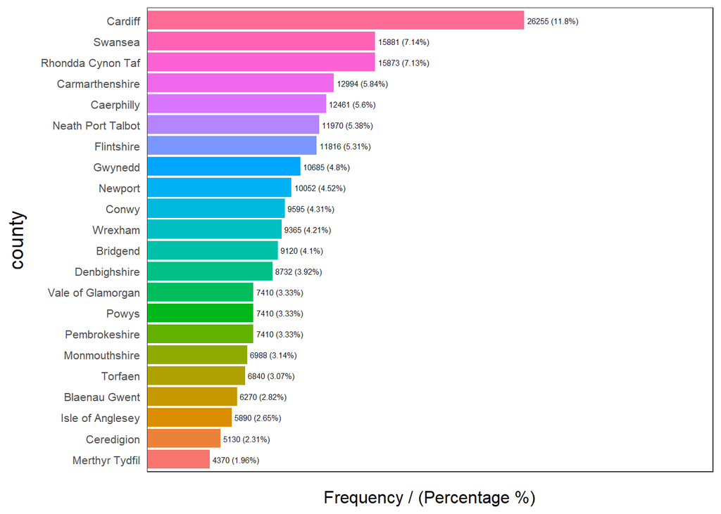

```
##               county frequency percentage cumulative_perc
## 1            Cardiff     26255      11.80           11.80
## 2            Swansea     15881       7.14           18.94
## 3  Rhondda Cynon Taf     15873       7.13           26.07
## 4    Carmarthenshire     12994       5.84           31.91
## 5         Caerphilly     12461       5.60           37.51
## 6  Neath Port Talbot     11970       5.38           42.89
## 7         Flintshire     11816       5.31           48.20
## 8            Gwynedd     10685       4.80           53.00
## 9            Newport     10052       4.52           57.52
## 10             Conwy      9595       4.31           61.83
## 11           Wrexham      9365       4.21           66.04
## 12          Bridgend      9120       4.10           70.14
## 13      Denbighshire      8732       3.92           74.06
## 14     Pembrokeshire      7410       3.33           77.39
## 15             Powys      7410       3.33           80.72
## 16 Vale of Glamorgan      7410       3.33           84.05
## 17     Monmouthshire      6988       3.14           87.19
## 18           Torfaen      6840       3.07           90.26
## 19     Blaenau Gwent      6270       2.82           93.08
## 20  Isle of Anglesey      5890       2.65           95.73
## 21        Ceredigion      5130       2.31           98.04
## 22    Merthyr Tydfil      4370       1.96          100.00
```

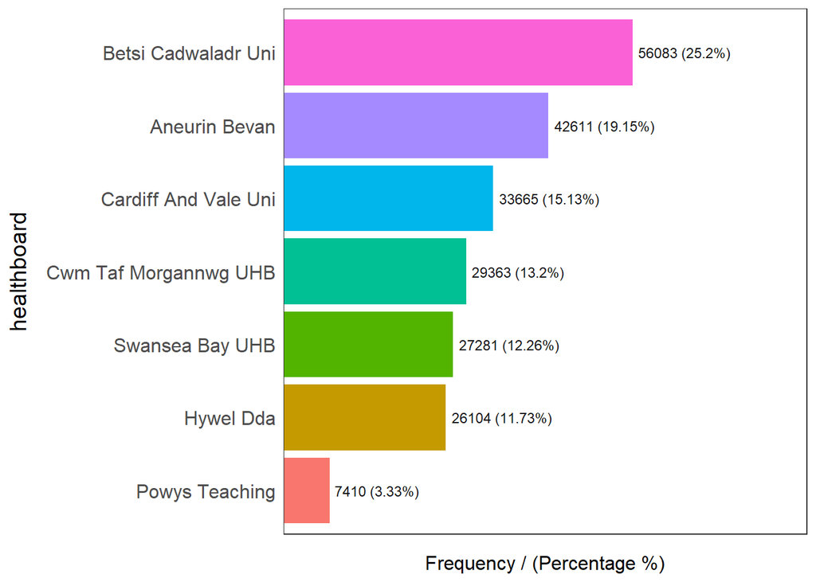

```
##             healthboard frequency percentage cumulative_perc
## 1   Betsi Cadwaladr Uni     56083      25.20           25.20
## 2         Aneurin Bevan     42611      19.15           44.35
## 3  Cardiff And Vale Uni     33665      15.13           59.48
## 4 Cwm Taf Morgannwg UHB     29363      13.20           72.68
## 5       Swansea Bay UHB     27281      12.26           84.94
## 6             Hywel Dda     26104      11.73           96.67
## 7        Powys Teaching      7410       3.33          100.00
##
##     lsoa_code frequency percentage cumulative_perc
## 1   W01000304      2280       1.02            1.02
## 2   W01000883      2280       1.02            2.04
## 3   W01001293      2280       1.02            3.06
## 4   W01000194      1710       0.77            3.83
## 5   W01000364      1710       0.77            4.60
```

[output cut: 1010 more lines]

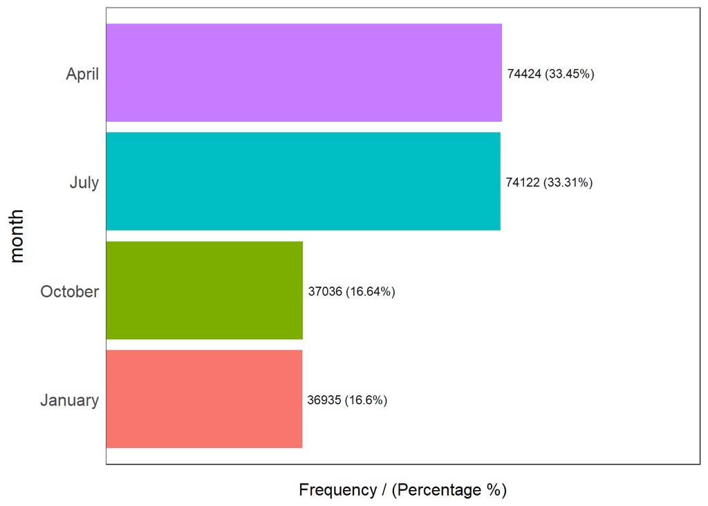

```
##     month frequency percentage cumulative_perc
## 1   April     74424      33.45           33.45
## 2    July     74122      33.31           66.76
## 3 October     37036      16.64           83.40
## 4 January     36935      16.60          100.00
##
##     postcode frequency percentage cumulative_perc
## 1    SA127BJ      2280       1.02            1.02
## 2    CF481BZ      1710       0.77            1.79
## 3    CF117DJ      1140       0.51            2.30
## 4    CF119SH      1140       0.51            2.81
## 5    CF717DA      1140       0.51            3.32
## 6     CH54PJ      1140       0.51            3.83
## 7     CH65ER      1140       0.51            4.34
## 8     CH73PG      1140       0.51            4.85
```

[output cut: 772 more lines]

```
## [1] "Variables processed: county, healthboard, lsoa_code, lsoa_name, lsoa_name_.cymraeg., month, postcode, practicecode"
```

The freq function from the funModeling package is great to quickly look at the frequencies in the dataset and creates some plots for us - with the Health Board Frequency plot looking very interesting.

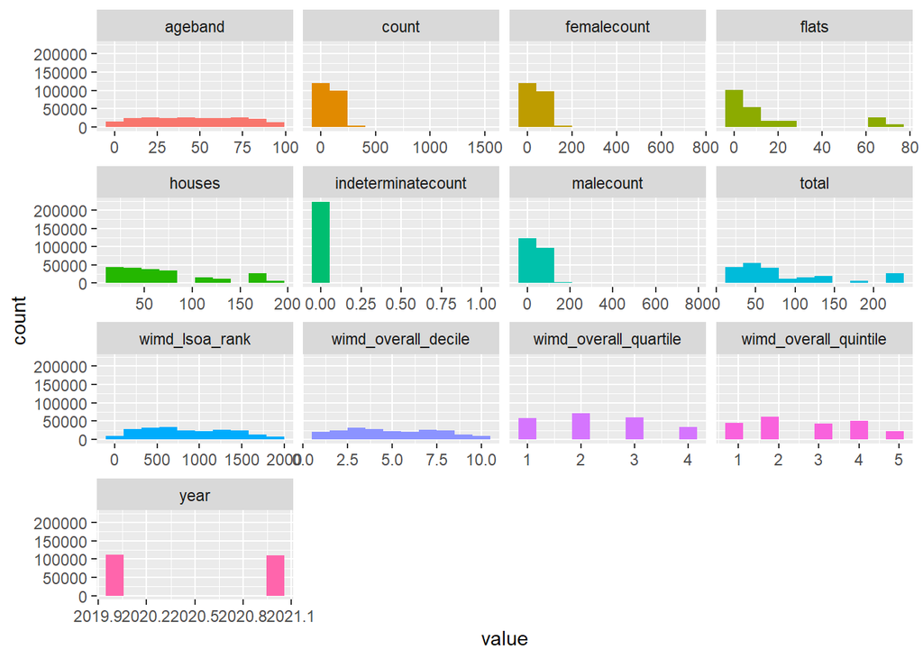

plot_num plots all of the numerical values within a dataset and plots them nicely, although this plot isn’t too interesting to us in this form.

Lets try to look at the average visits per GP.

[figure not shown]

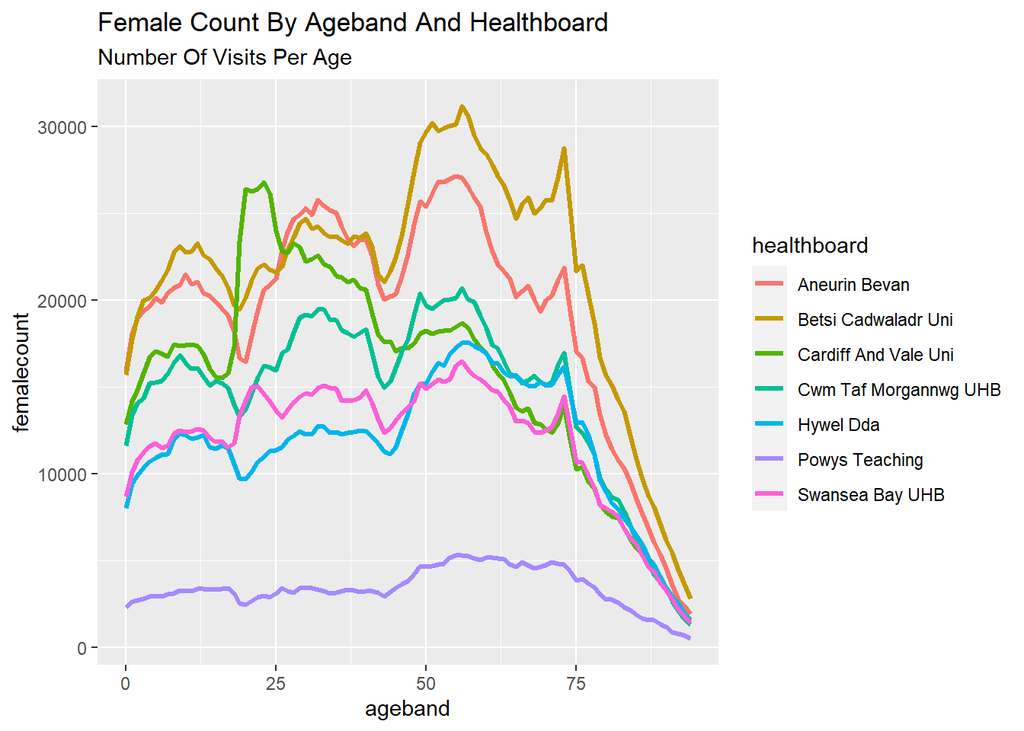

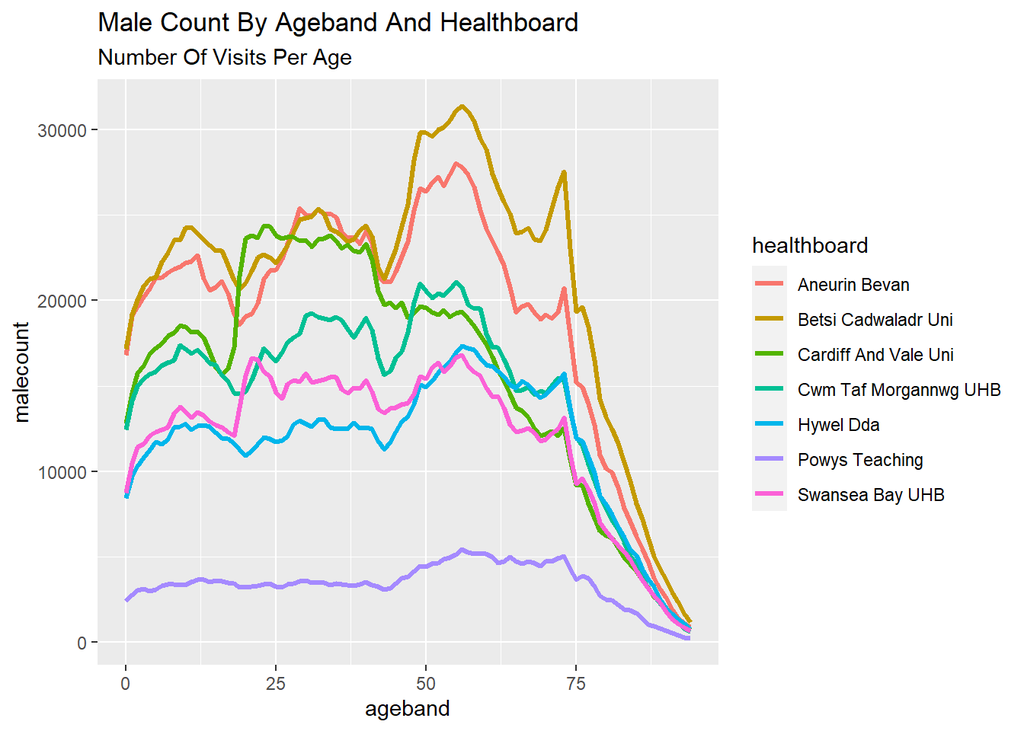

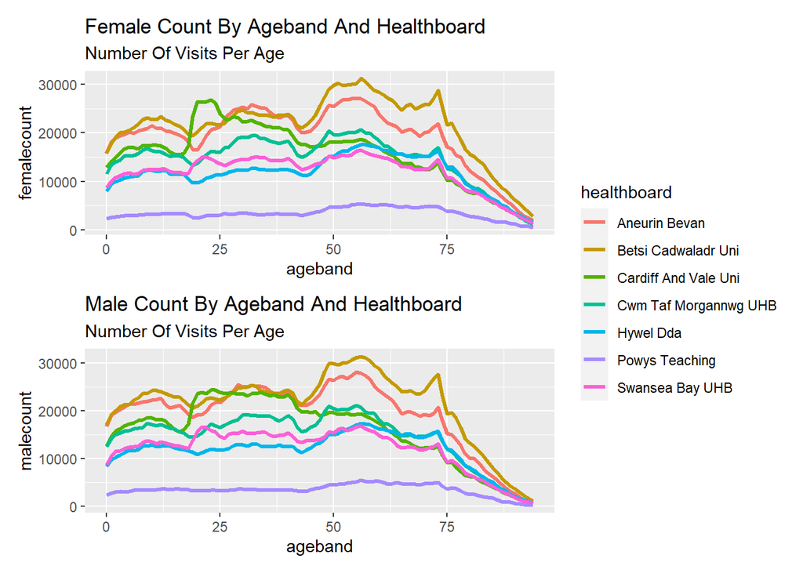

# 5 - Hypothesis Testing

Before carrying out any Hypothesis tests, usually in ML projects the data would need to be normalised or standardised somehow. From a quick search online, there are two ways to do this within R.

With the function now created to normalise the data, this could be useful in furute research, especially if moving to ML.

But for now, we will explore the data as it is and start with covering some t.tests and see if these could be useful.

```
## (Intercept)
##    847.6237
```

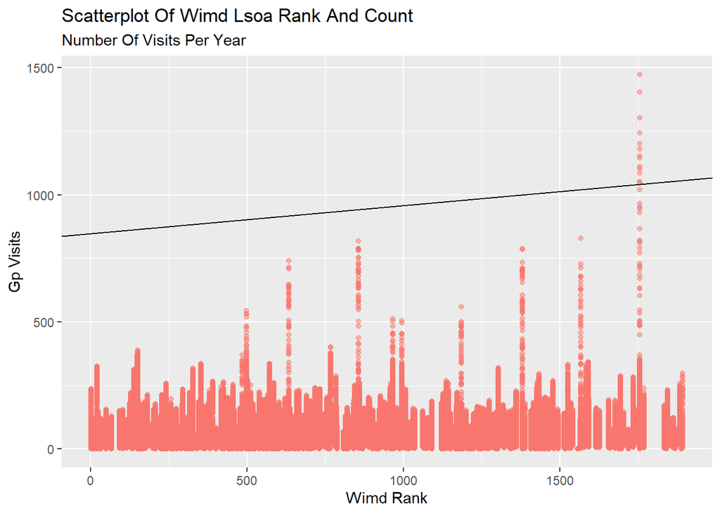

```
##             Length Class  Mode
## statistic   1      -none- numeric
## parameter   0      -none- NULL
## p.value     1      -none- numeric
## estimate    1      -none- numeric
## null.value  1      -none- numeric
## alternative 1      -none- character
## method      1      -none- character
## data.name   1      -none- character
```

This section will go over how to carry out a T-test on the *GP Visits modelled by the year*.

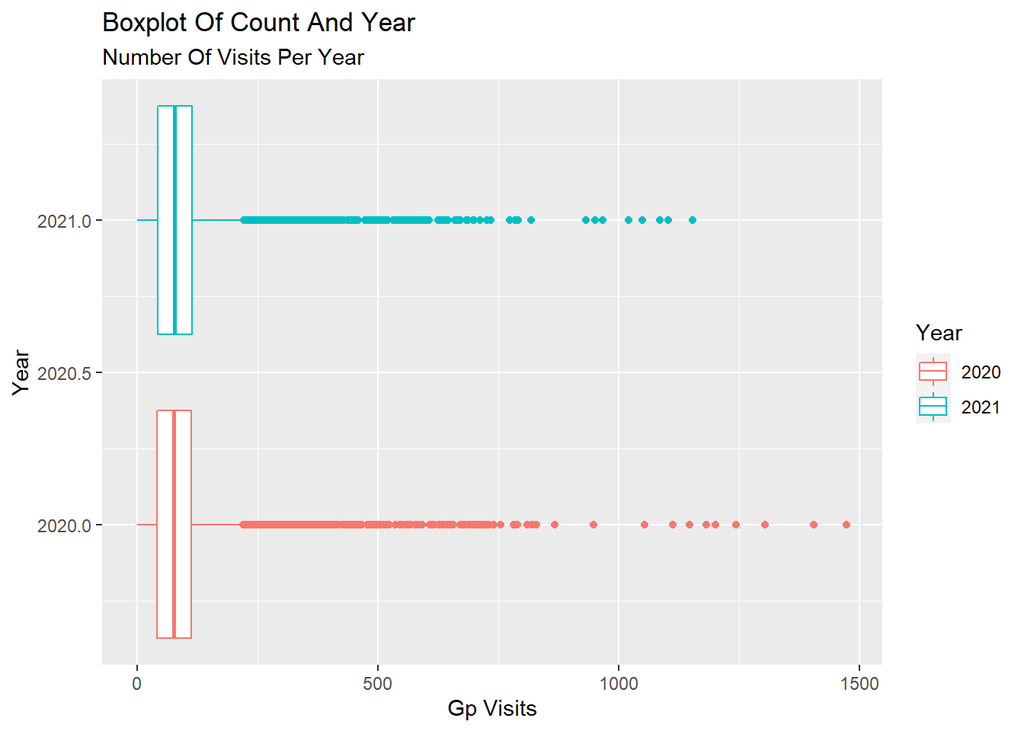

|  | Df | F value | Pr(>F) |
| --- | --- | --- | --- |
| group | 1 | 1.30682 | 0.2529724 |
|  | 222515 | NA | NA |

```
##
##  Two Sample t-test
##
## data:  df$count by df$year
## t = -6.4299, df = 222515, p-value = 1.279e-10
## alternative hypothesis: true difference in means between group 2020 and group 2021 is not equal to 0
## 95 percent confidence interval:
##  -2.094381 -1.115840
## sample estimates:
## mean in group 2020 mean in group 2021
##           83.20262           84.80773
```

This next section will cover how to carry out an ANOVA analysis, of the data *GP Visits modelled by County*.

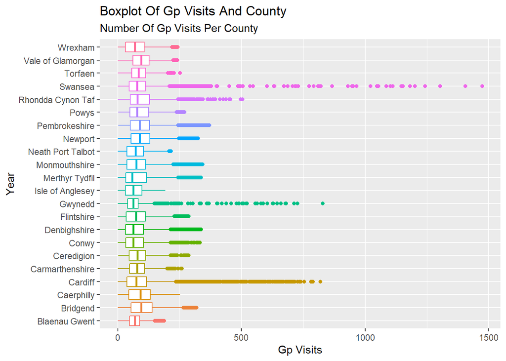

```
##                 Df    Sum Sq Mean Sq F value Pr(>F)
## df$county       21  21730310 1034777   307.1 <2e-16 ***
## Residuals   222495 749703782    3370
## ---
## Signif. codes:  0 '***' 0.001 '**' 0.01 '*' 0.05 '.' 0.1 ' ' 1
```

```
##   Tukey multiple comparisons of means
##     95% family-wise confidence level
##
## Fit: aov(formula = df$count ~ df$county)
##
## $`df$county`
##                                             diff         lwr          upr
## Bridgend-Blaenau Gwent               36.32351475  32.9019596  39.74506995
## Caerphilly-Blaenau Gwent             21.65290792  18.4236280  24.88218785
## Cardiff-Blaenau Gwent                18.60058982  15.6689926  21.53218703
## Carmarthenshire-Blaenau Gwent        11.79576934   8.5887361  15.00280259
## Ceredigion-Blaenau Gwent             14.60756690  10.6811591  18.53397468
## Conwy-Blaenau Gwent                   4.41301341   1.0261381   7.79988871
## Denbighshire-Blaenau Gwent            8.46277411   5.0103879  11.91516035
## Flintshire-Blaenau Gwent              9.47821363   6.2195639  12.73686336
## Gwynedd-Blaenau Gwent                -1.97885848  -5.2967585   1.33904152
## Isle of Anglesey-Blaenau Gwent       -1.55326439  -5.3377843   2.23125556
## Merthyr Tydfil-Blaenau Gwent         15.31266902  11.2027643  19.42257375
## Monmouthshire-Blaenau Gwent          14.58458643  10.9566120  18.21256086
## Neath Port Talbot-Blaenau Gwent       4.98528898   1.7339144   8.23666352
## Newport-Blaenau Gwent                26.68357136  23.3272611  30.03988166
## Pembrokeshire-Blaenau Gwent          29.33092872  25.7521438  32.90971368
## Powys-Blaenau Gwent                  20.02903938  16.4502544  23.60782434
## Rhondda Cynon Taf-Blaenau Gwent      24.27642206  21.1654910  27.38735308
## Swansea-Blaenau Gwent                23.13100127  20.0202921  26.24171040
## Torfaen-Blaenau Gwent                16.33846358  12.6919742  19.98495297
## Vale of Glamorgan-Blaenau Gwent      27.64887744  24.0700925  31.22766240
## Wrexham-Blaenau Gwent                 5.40710959   2.0038372   8.81038199
## Caerphilly-Bridgend                 -14.67060683 -17.5446769 -11.79653681
## Cardiff-Bridgend                    -17.72292494 -20.2579381 -15.18791175
## Carmarthenshire-Bridgend            -24.52774541 -27.3767965 -21.67869436
## Ceredigion-Bridgend                 -21.71594786 -25.3558253 -18.07607042
## Conwy-Bridgend                      -31.91050135 -34.9605758 -28.86042692
## Denbighshire-Bridgend               -27.86074064 -30.9833998 -24.73808146
## Flintshire-Bridgend                 -26.84530112 -29.7523319 -23.93827038
## Gwynedd-Bridgend                    -38.30237323 -41.2756694 -35.32907707
## Isle of Anglesey-Bridgend           -37.87677915 -41.3631269 -34.39043136
## Merthyr Tydfil-Bridgend             -21.01084573 -24.8479470 -17.17374441
## Monmouthshire-Bridgend              -21.73892833 -25.0546829 -18.42317379
## Neath Port Talbot-Bridgend          -31.33822577 -34.2370990 -28.43935253
```

[output cut: 415 more lines]

```
## Rhondda Cynon Taf-Powys             0.0000443
## Swansea-Powys                       0.0245872
## Torfaen-Powys                       0.0251877
## Vale of Glamorgan-Powys             0.0000000
## Wrexham-Powys                       0.0000000
## Swansea-Rhondda Cynon Taf           0.9811113
## Torfaen-Rhondda Cynon Taf           0.0000000
## Vale of Glamorgan-Rhondda Cynon Taf 0.0069022
## Wrexham-Rhondda Cynon Taf           0.0000000
## Torfaen-Swansea                     0.0000000
## Vale of Glamorgan-Swansea           0.0000072
## Wrexham-Swansea                     0.0000000
## Vale of Glamorgan-Torfaen           0.0000000
## Wrexham-Torfaen                     0.0000000
## Wrexham-Vale of Glamorgan           0.0000000
```

```
##
##  Kruskal-Wallis rank sum test
##
## data:  df$count by df$county
## Kruskal-Wallis chi-squared = 6398.8, df = 21, p-value < 2.2e-16
```

Linear Regression to look at the relationship between number of newly built houses vs the number of GP visits.

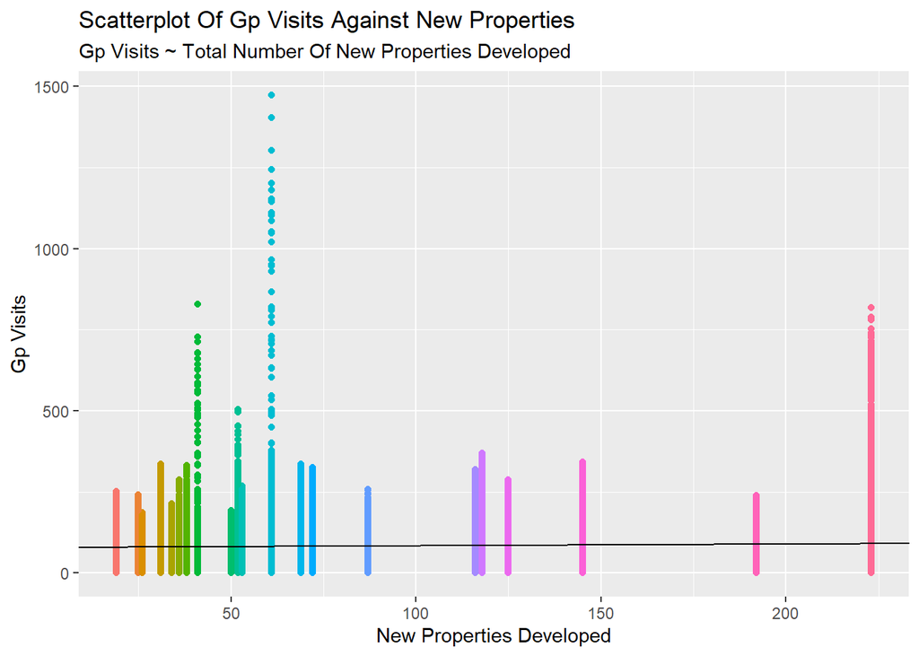

```
##
## Call:
## lm(formula = count ~ total, data = df)
##
## Residuals:
##     Min      1Q  Median      3Q     Max
##  -91.17  -42.07   -7.64   28.93 1390.36
##
## Coefficients:
##             Estimate Std. Error t value Pr(>|t|)
## (Intercept) 79.43137    0.21076  376.88   <2e-16 ***
## total        0.05266    0.00196   26.86   <2e-16 ***
## ---
## Signif. codes:  0 '***' 0.001 '**' 0.01 '*' 0.05 '.' 0.1 ' ' 1
##
## Residual standard error: 58.79 on 222515 degrees of freedom
## Multiple R-squared:  0.003233,   Adjusted R-squared:  0.003228
## F-statistic: 721.7 on 1 and 222515 DF,  p-value: < 2.2e-16
```

```
##
## Call:  glm(formula = count ~ total, data = df)
##
## Coefficients:
## (Intercept)        total
##    79.43137      0.05266
##
## Degrees of Freedom: 222516 Total (i.e. Null);  222515 Residual
## Null Deviance:       771400000
## Residual Deviance: 768900000     AIC: 2444000
```